# Smouldering and flaming fire in mined and unmined upland swamps

```r
library(ggplot2)
library(dplyr)
library(DHARMa)
library(emmeans)
library(parameters)
library(table1)
library(lubridate)
library(ggpubr)
```

load data

```r
datadir <- "../data"
locations<- read.csv(file.path(datadir, "Sod_locations.csv"))
smouldering <-read.csv(file.path(datadir, "TM6_Complete_Sod_Data_main.csv"))
flaming <- read.csv(file.path(datadir,"Sod_Data_flaming_moist_som_main.csv"))
probes <- read.csv(file.path(datadir,"all_probes_2012_2017_ver6_for_comb.csv")) %>%
  mutate(date = dmy(date))
```

tabulate data

```r
table1(~grav_moist_dec2023+bd_g_per_cm3_May23+som_percent_Jan24|Fire_treat+binomial_iCone_burn_status,data=flaming)
```

|  | High 0 (N=37) | High 1 (N=18) | Low 0 (N=39) | Low 1 (N=18) | Overall 0 (N=76) | Overall 1 (N=36) |
| --- | --- | --- | --- | --- | --- | --- |
| grav_moist_dec2023 |  |  |  |  |  |  |
| Mean (SD) | 2.54 (2.01) | 0.319 (0.409) | 2.27 (1.69) | 0.197 (0.0871) | 2.40 (1.84) | 0.258 (0.298) |
| Median [Min, Max] | 2.04 [0.276, 11.1] | 0.236 [0.0906, 1.93] | 2.03 [0.0552, 7.18] | 0.189 [0.0868, 0.397] | 2.03 [0.0552, 11.1] | 0.198 [0.0868, 1.93] |
| bd_g_per_cm3_May23 |  |  |  |  |  |  |
| Mean (SD) | 0.309 (0.179) | 0.339 (0.192) | 0.320 (0.206) | 0.303 (0.129) | 0.315 (0.192) | 0.321 (0.162) |
| Median [Min, Max] | 0.241 [0.0917, 0.807] | 0.289 [0.123, 0.820] | 0.251 [0.129, 1.25] | 0.253 [0.142, 0.514] | 0.246 [0.0917, 1.25] | 0.280 [0.123, 0.820] |
| som_percent_Jan24 |  |  |  |  |  |  |
| Mean (SD) | 37.3 (21.2) | 45.3 (24.4) | 40.6 (23.2) | 44.5 (19.5) | 39.0 (22.2) | 44.9 (21.8) |
| Median [Min, Max] | 34.9 [4.54, 79.1] | 40.3 [13.9, 90.2] | 38.7 [7.52, 97.4] | 43.2 [8.63, 84.4] | 37.6 [4.54, 97.4] | 43.2 [8.63, 90.2] |

### Explore: flaming fire - BAL40

```r
burn_data_bal40 <- flaming %>%
  filter(!Sample=='MH CH 19') %>% # remove outlier
  left_join(locations) %>%
  mutate(binomial_burn_status = binomial_iCone_burn_status,
         grav_moist_percent = grav_moist_percent_dec2023,
         som_percent = som_percent_Jan24,
         bd_g_per_cm3 = bd_g_per_cm3_May23,
         volumetric_wc = grav_moist_percent * bd_g_per_cm3) %>%
  filter(Fire_treat == "Low")
ft.burning_bal40 <- glm(binomial_burn_status ~ volumetric_wc , family=binomial, data = burn_data_bal40)
summary(ft.burning_bal40)
```

```
##
## Call:
## glm(formula = binomial_burn_status ~ volumetric_wc, family = binomial,
##     data = burn_data_bal40)
##
## Coefficients:
##               Estimate Std. Error z value Pr(>|z|)
## (Intercept)     2.8967     1.0294   2.814  0.00489 **
## volumetric_wc  -0.2603     0.1087  -2.395  0.01660 *
## ---
## Signif. codes:  0 '***' 0.001 '**' 0.01 '*' 0.05 '.' 0.1 ' ' 1
##
## (Dispersion parameter for binomial family taken to be 1)
##
##     Null deviance: 71.097  on 56  degrees of freedom
## Residual deviance: 25.010  on 55  degrees of freedom
## AIC: 29.01
##
## Number of Fisher Scoring iterations: 9
```

Check assumptions

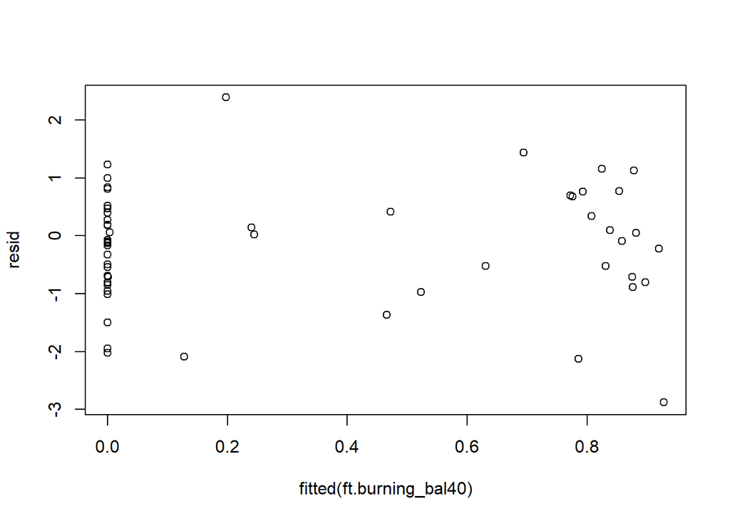

```r
sim= simulateResiduals(ft.burning_bal40)
resid = residuals(sim, quantileFunction = qnorm, outlierValues = c(-7,7))
plot(resid~fitted(ft.burning_bal40))
```

### Inference

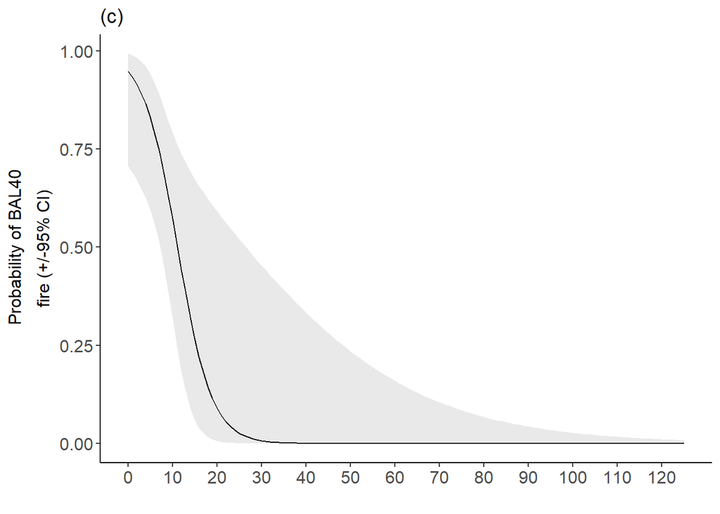

```r
em_grav_bal40 = emmip(ft.burning_bal40, ~ volumetric_wc , type = "response",  CIs = TRUE,
      at = list(volumetric_wc = seq(0, 150,by=1)), plotit = FALSE)




#write.csv(em_grav_bal40,file="em_grav_BAL40.csv")

BAL40_plot <- ggplot(em_grav_bal40, aes(volumetric_wc, yvar)) +
  geom_ribbon(aes(ymin = LCL, ymax = UCL), alpha = 0.5, fill = "lightgrey")+
  geom_line()+
  #geom_point(colour = "grey25", data = burn_data, aes(volumetric_wc,binomial_burn_status)) +
  ylab(expression(atop(paste("Probability of BAL40"), paste("fire (+/-95% CI)"))))+
  scale_x_continuous(breaks = seq(0, 120, by = 10), limits = c(0,125))+
  xlab("")+
 # geom_vline(xintercept = 50)+ #tells us what the value and CI are when grav moist is 50%
  theme(axis.text = element_text(size = 12))+
  theme(axis.title = element_text(size = 12))+
  theme(plot.title = element_text(size = 14))+
  theme(strip.text = element_text(size = 14))+
  theme(legend.text = element_text(size = 12))+
  labs(title = "(c)")+
    theme(panel.grid.major = element_blank(), panel.grid.minor = element_blank(),
        panel.background = element_blank(), axis.line = element_line(colour = "black"))
BAL40_plot
```

```r
# ggsave(plot = BAL40_plot, file = "../results/BAL40_plot.tiff" , width = 180, height = 150, units = "mm", device = "tiff")
  #geom_vline(xintercept = 10)
```

Choose a common time period across probes

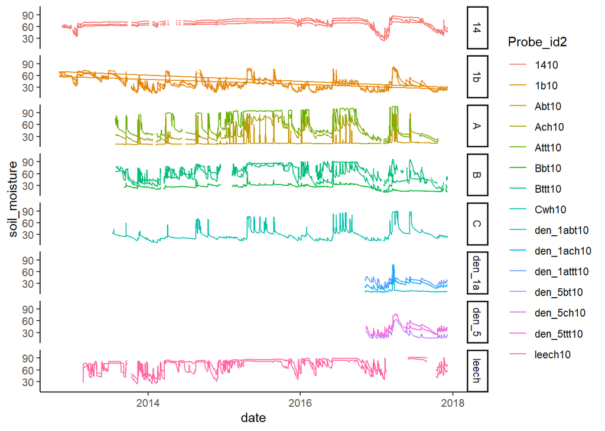

```r
probes %>%
  filter(Probe_depth == 10) %>%
ggplot(aes(date, soil_moisture, color = Probe_id2))+
  geom_path()+
  facet_grid(Swamp ~ .)+
  theme_classic()
```

Starting at when den_5 starts, 11/12/2016. Only include ch and tt and 10cm depth

```r
probes_sub <- probes %>%
  filter(Probe_depth == 10,
         veg_type != "bt",
         veg_type != "wh",
         Impact != "Unknown",
         date > dmy("11/12/2016"),
         !is.na(soil_moisture))


table1(~Probe_id|Swamp+veg_type,data=probes_sub) #there are seven swamps that are included
```

|  | 14 ch (N=1080) | 1b ch (N=360) | A ch (N=306) | A ttt (N=261) | B ttt (N=610) | den_1a ch (N=360) | den_1a ttt (N=360) | den_5 ch (N=205) | den_5 ttt (N=360) | leech ttt (N=436) | Overall ch (N=2311) | Overall ttt (N=2027) |
| --- | --- | --- | --- | --- | --- | --- | --- | --- | --- | --- | --- | --- |
| Probe_id |  |  |  |  |  |  |  |  |  |  |  |  |
| soil_1_W_1_S14cal | 360 (33.3%) | 0 (0%) | 0 (0%) | 0 (0%) | 0 (0%) | 0 (0%) | 0 (0%) | 0 (0%) | 0 (0%) | 0 (0%) | 360 (15.6%) | 0 (0%) |
| soil_2_W_1_S14cal | 360 (33.3%) | 0 (0%) | 0 (0%) | 0 (0%) | 0 (0%) | 0 (0%) | 0 (0%) | 0 (0%) | 0 (0%) | 0 (0%) | 360 (15.6%) | 0 (0%) |
| soil_3_W_1_S14cal | 360 (33.3%) | 0 (0%) | 0 (0%) | 0 (0%) | 0 (0%) | 0 (0%) | 0 (0%) | 0 (0%) | 0 (0%) | 0 (0%) | 360 (15.6%) | 0 (0%) |
| soil_2_W_1_S1bcal | 0 (0%) | 360 (100%) | 0 (0%) | 0 (0%) | 0 (0%) | 0 (0%) | 0 (0%) | 0 (0%) | 0 (0%) | 0 (0%) | 360 (15.6%) | 0 (0%) |
| A_ch_0_10 | 0 (0%) | 0 (0%) | 306 (100%) | 0 (0%) | 0 (0%) | 0 (0%) | 0 (0%) | 0 (0%) | 0 (0%) | 0 (0%) | 306 (13.2%) | 0 (0%) |
| A_ttt_1_10 | 0 (0%) | 0 (0%) | 0 (0%) | 261 (100%) | 0 (0%) | 0 (0%) | 0 (0%) | 0 (0%) | 0 (0%) | 0 (0%) | 0 (0%) | 261 (12.9%) |
| B_ttt_1_10 | 0 (0%) | 0 (0%) | 0 (0%) | 0 (0%) | 342 (56.1%) | 0 (0%) | 0 (0%) | 0 (0%) | 0 (0%) | 0 (0%) | 0 (0%) | 342 (16.9%) |
| B_ttt_2_10 | 0 (0%) | 0 (0%) | 0 (0%) | 0 (0%) | 268 (43.9%) | 0 (0%) | 0 (0%) | 0 (0%) | 0 (0%) | 0 (0%) | 0 (0%) | 268 (13.2%) |
| den_1a_ch_1_10 | 0 (0%) | 0 (0%) | 0 (0%) | 0 (0%) | 0 (0%) | 360 (100%) | 0 (0%) | 0 (0%) | 0 (0%) | 0 (0%) | 360 (15.6%) | 0 (0%) |
| den_1a_ttt_2_10 | 0 (0%) | 0 (0%) | 0 (0%) | 0 (0%) | 0 (0%) | 0 (0%) | 360 (100%) | 0 (0%) | 0 (0%) | 0 (0%) | 0 (0%) | 360 (17.8%) |
| den_5_ch_0_10 | 0 (0%) | 0 (0%) | 0 (0%) | 0 (0%) | 0 (0%) | 0 (0%) | 0 (0%) | 205 (100%) | 0 (0%) | 0 (0%) | 205 (8.9%) | 0 (0%) |
| den_5_ttt_2_10 | 0 (0%) | 0 (0%) | 0 (0%) | 0 (0%) | 0 (0%) | 0 (0%) | 0 (0%) | 0 (0%) | 360 (100%) | 0 (0%) | 0 (0%) | 360 (17.8%) |
| soil_2_W_1_leechcal | 0 (0%) | 0 (0%) | 0 (0%) | 0 (0%) | 0 (0%) | 0 (0%) | 0 (0%) | 0 (0%) | 0 (0%) | 218 (50.0%) | 0 (0%) | 218 (10.8%) |
| soil_3_W_1_leechcal | 0 (0%) | 0 (0%) | 0 (0%) | 0 (0%) | 0 (0%) | 0 (0%) | 0 (0%) | 0 (0%) | 0 (0%) | 218 (50.0%) | 0 (0%) | 218 (10.8%) |

We then look at the distribution of soil moisture for the undermined and reference sites.

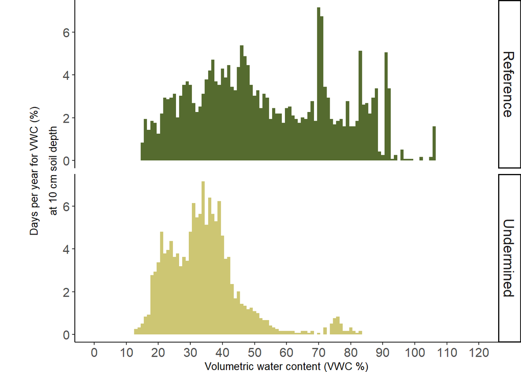

```r
moisture_plot <- probes_sub %>%
  ggplot(aes(soil_moisture, fill = Impact))+
  # geom_histogram(aes(y=..density..), binwidth = 1) +
  geom_histogram(aes(y=..count../sum(..count..)*365), binwidth = 1) +
  facet_grid(Impact ~ .)+
  scale_fill_manual(values=c("darkolivegreen", "khaki3"))+
  theme_classic()+
  theme(legend.position = "none")+
    xlab("Volumetric water content (VWC %)")+
    scale_x_continuous(breaks = seq(0, 125, by = 10), limits = c(0, 120))+
  #ylab("Days per year")+
  ylab(expression(atop(paste("Days per year for VWC (%)"), paste("at 10 cm soil depth"))))+
  theme(axis.text = element_text(size = 12))+
  theme(axis.title = element_text(size = 10))+
  theme(plot.title = element_text(size = 14))+
  theme(strip.text = element_text(size = 14))+
  theme(legend.text = element_text(size = 12))+
    theme(plot.margin = unit(c(0,0,0,1), "cm"))

moisture_plot
```

We can calculate an average probability of burning by multiplying the soil moisture for each day by the probability of burning for that soil moisture, and averaging across the days.

```r
probes_summary <- probes_sub %>%
  mutate(xvar = round(soil_moisture)) %>% #round to nearest integer
  group_by(Impact, xvar) %>%
  count() %>% # count how many days for each soil moisture value
  left_join(em_grav_bal40) %>%
  mutate(pn_burn = yvar * n) %>% # multiply this histogram by probability of burning
  group_by(Impact) %>%
  summarise(n = sum(n), probn = sum(pn_burn)) %>%
  transmute(Impact, p_burn = probn/n) # averaging
probes_summary
```

| Impact | p_burn |
| --- | --- |
| Reference | 0.01050306 |
| Undermined | 0.02218764 |

The average (per day) probability of flaming (BAL40) fire is doubled, from 1.1% for reference to 2.2% for undermined.

We can then generate CI for the difference between Reference and Undermined probabilities by simulating from the posterior distribution of the model coefficients, and calculating a percentile confidence interval.

```r
library(mvtnorm)
library(tidyr)
K=100 #change to 1000 to get better estimate
set.seed(111024)
sim_pars<-rmvnorm(K,coef(ft.burning_bal40),vcov(ft.burning_bal40))

burning_probs <- data.frame(Reference = rep(NA, K), Undermined = NA)

for(i in 1:K){
  nu <- sim_pars[i,1]+em_grav_bal40$volumetric_wc*sim_pars[i,2]
  p <- 1/(1+exp(-nu))
  sim_p <- data.frame(xvar =em_grav_bal40$volumetric_wc, yvar = p)

  burning_probs[i,] <- probes_sub %>%
  mutate(xvar = round(soil_moisture)) %>% #round to nearest integer
  group_by(Impact, xvar) %>%
  count() %>% # count how many days for each soil moisture value
  left_join(sim_p) %>%
  mutate(pn_burn = yvar * n) %>% # multiply this histogram by probability of burning
  group_by(Impact) %>%
  summarise(n = sum(n), probn = sum(pn_burn)) %>%
  transmute(Impact, p_burn = probn/n) %>%
    pivot_wider(names_from = Impact, values_from = p_burn)
}
# Difference

c(probes_summary[2,2] / probes_summary[1,2],

quantile((burning_probs$Undermined / burning_probs$Reference), probs = c(0.025, 0.975)))
```

```
## $p_burn
## [1] 2.112492
##
## $`2.5%`
## [1] 1.686278
##
## $`97.5%`
## [1] 2.222336
```

The average (per day) probability of flaming (BAL40) fire is more than double (ratio = 2.11, 95%CI = 1.69 - 2.22), from 1.1% for reference to 2.2% for undermined.

### Explore: flaming fire - BALFZ

```r
burn_data_fz <- flaming %>%
  filter(!Sample=='MH CH 19') %>% # remove outlier
  left_join(locations) %>%
  mutate(binomial_burn_status = binomial_iCone_burn_status,
         grav_moist_percent = grav_moist_percent_dec2023,
         som_percent = som_percent_Jan24,
         bd_g_per_cm3 = bd_g_per_cm3_May23,
         volumetric_wc = grav_moist_percent * bd_g_per_cm3) %>%
  filter(Fire_treat == "High")
ft.burning_fz <- glm(binomial_burn_status ~ volumetric_wc , family=binomial, data = burn_data_fz)

summary(ft.burning_fz)
```

```
##
## Call:
## glm(formula = binomial_burn_status ~ volumetric_wc, family = binomial,
##     data = burn_data_fz)
##
## Coefficients:
##               Estimate Std. Error z value Pr(>|z|)
## (Intercept)    4.92083    1.69740   2.899  0.00374 **
## volumetric_wc -0.22229    0.07117  -3.123  0.00179 **
## ---
## Signif. codes:  0 '***' 0.001 '**' 0.01 '*' 0.05 '.' 0.1 ' ' 1
##
## (Dispersion parameter for binomial family taken to be 1)
##
##     Null deviance: 68.744  on 53  degrees of freedom
## Residual deviance: 14.576  on 52  degrees of freedom
## AIC: 18.576
##
## Number of Fisher Scoring iterations: 8
```

Check assumptions

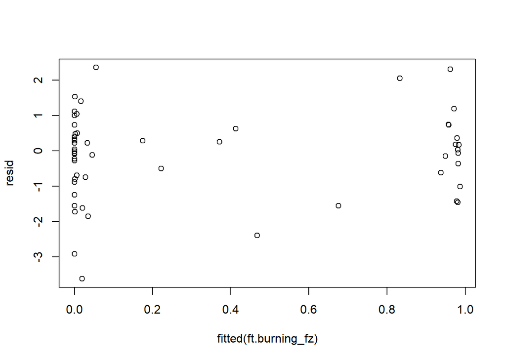

```r
sim= simulateResiduals(ft.burning_fz)
resid = residuals(sim, quantileFunction = qnorm, outlierValues = c(-7,7))
plot(resid~fitted(ft.burning_fz))
```

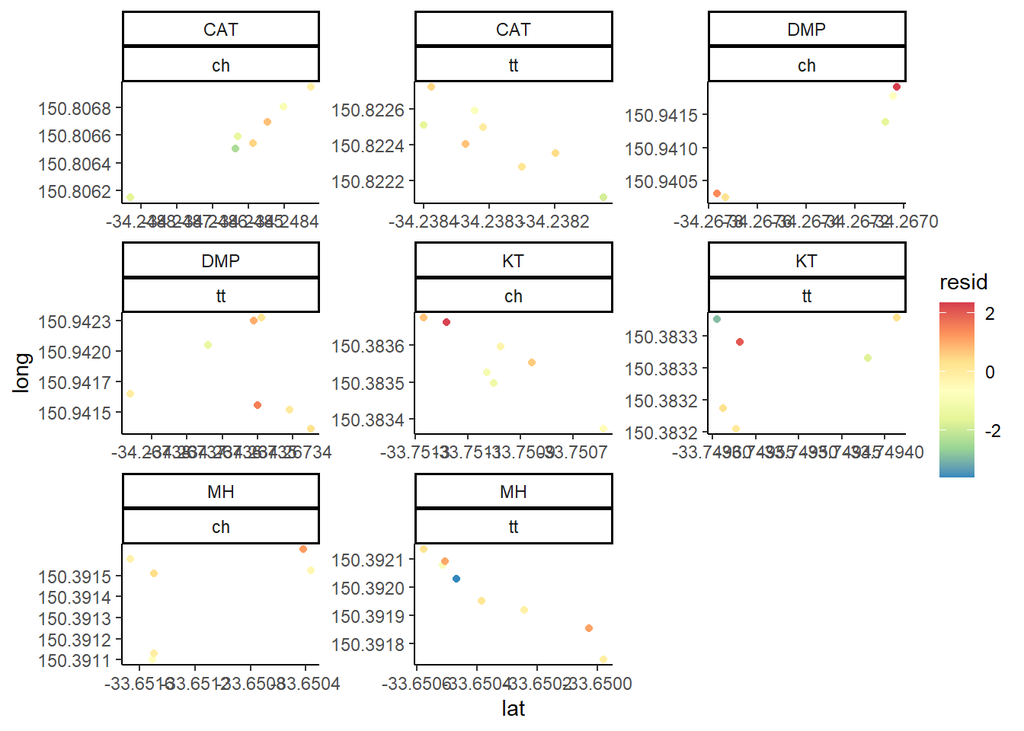

```r
burn_data_fz$resid = resid
ggplot(burn_data_fz, aes(lat,long, colour = resid)) +
  geom_point() +
  facet_wrap(swamp~  veg, scales = "free")+
  scale_colour_distiller(palette = "Spectral")+
  theme_classic()
```

### Inference

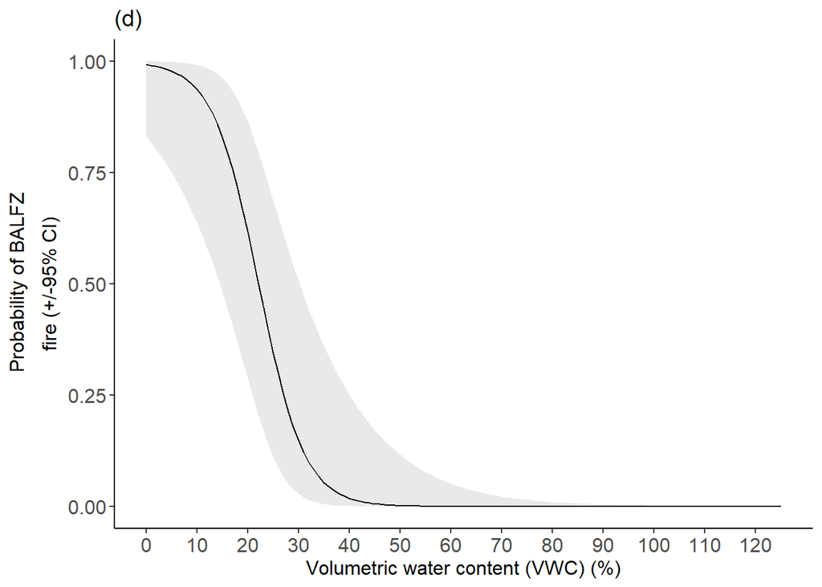

```r
em_grav_fz = emmip(ft.burning_fz, ~ volumetric_wc , type = "response",  CIs = TRUE,
      at = list(volumetric_wc = seq(0, 150,by=1)), plotit = FALSE)




#write.csv(em_grav_fz,file="em_grav_fz.csv")

BALFZ_plot <- ggplot(em_grav_fz, aes(volumetric_wc, yvar)) +
  geom_ribbon(aes(ymin = LCL, ymax = UCL), alpha = 0.5, fill = "lightgrey")+
  geom_line()+
  #geom_point(colour = "grey25", data = burn_data_fz, aes(volumetric_wc,binomial_burn_status)) +
  ylab(expression(atop(paste("Probability of BALFZ"), paste("fire (+/-95% CI)"))))+
  scale_x_continuous(breaks = seq(0, 120, by = 10), limits = c(0,125))+
  xlab("Volumetric water content (VWC) (%)")+
  # geom_vline(xintercept = 50)+ #tells us what the value and CI are when grav moist is 50%
  theme(axis.text = element_text(size = 12))+
  theme(axis.title = element_text(size = 12))+
  theme(plot.title = element_text(size = 14))+
  theme(strip.text = element_text(size = 14))+
  theme(legend.text = element_text(size = 12))+
  labs(title = "(d)")+
    theme(panel.grid.major = element_blank(), panel.grid.minor = element_blank(),
        panel.background = element_blank(), axis.line = element_line(colour = "black"))
BALFZ_plot
```

```r
# ggsave(plot = BALFZ_plot, file = "../results/BALFZ_plot.tiff" , width = 180, height = 150, units = "mm", device = "tiff")
  #geom_vline(xintercept = 10)
```

```r
probes_summary <- probes_sub %>%
  mutate(xvar = round(soil_moisture)) %>% #round to nearest integer
  group_by(Impact, xvar) %>%
  count() %>% # count how many days for each soil moisture value
  left_join(em_grav_fz) %>%
  mutate(pn_burn = yvar * n) %>% # multiply this histogram by probability of burning
  group_by(Impact) %>%
  summarise(n = sum(n), probn = sum(pn_burn)) %>%
  transmute(Impact, p_burn = probn/n) # averaging
probes_summary
```

| Impact | p_burn |
| --- | --- |
| Reference | 0.08063516 |
| Undermined | 0.18292036 |

The average (per day) probability of flaming (FZ) fire is more than double, from 8.1% for reference to 18.3% for undermined.

We can then generate CI for the difference between Reference and Undermined probabilities by simulating from the posterior distribution of the model coefficients, and calculating a percentile confidence interval.

```r
library(mvtnorm)
library(tidyr)
K=100 #change to 1000 to get better estimate
set.seed(111024)
sim_pars<-rmvnorm(K,coef(ft.burning_fz),vcov(ft.burning_fz))

burning_probs <- data.frame(Reference = rep(NA, K), Undermined = NA)

for(i in 1:K){
  nu <- sim_pars[i,1]+em_grav_fz$volumetric_wc*sim_pars[i,2]
  p <- 1/(1+exp(-nu))
  sim_p <- data.frame(xvar =em_grav_fz$volumetric_wc, yvar = p)

  burning_probs[i,] <- probes_sub %>%
  mutate(xvar = round(soil_moisture)) %>% #round to nearest integer
  group_by(Impact, xvar) %>%
  count() %>% # count how many days for each soil moisture value
  left_join(sim_p) %>%
  mutate(pn_burn = yvar * n) %>% # multiply this histogram by probability of burning
  group_by(Impact) %>%
  summarise(n = sum(n), probn = sum(pn_burn)) %>%
  transmute(Impact, p_burn = probn/n) %>%
    pivot_wider(names_from = Impact, values_from = p_burn)
}
# Difference

c(probes_summary[2,2] / probes_summary[1,2],

quantile((burning_probs$Undermined / burning_probs$Reference), probs = c(0.025, 0.975)))
```

```
## $p_burn
## [1] 2.268494
##
## $`2.5%`
## [1] 1.988219
##
## $`97.5%`
## [1] 2.288262
```

The average (per day) probability of burning is more than double (ratio = 2.27, 95%CI = 1.99 - 2.29), from 8.1% for reference to 18.3% for undermined.

### Explore: smouldering fire

```r
burn_data_smould <- smouldering %>%
  filter(!Sample=='MH CH 19') %>% # remove outlier
  left_join(locations) %>%
  mutate(volumetric_wc = grav_moist_percent * bd_g_per_cm3)
ft.burning_smould <- glm(binomial_burn_status ~ volumetric_wc , family=binomial, data = burn_data_smould)

summary(ft.burning_smould)
```

```
##
## Call:
## glm(formula = binomial_burn_status ~ volumetric_wc, family = binomial,
##     data = burn_data_smould)
##
## Coefficients:
##               Estimate Std. Error z value Pr(>|z|)
## (Intercept)    4.22199    1.11986   3.770 0.000163 ***
## volumetric_wc -0.25798    0.08307  -3.105 0.001900 **
## ---
## Signif. codes:  0 '***' 0.001 '**' 0.01 '*' 0.05 '.' 0.1 ' ' 1
##
## (Dispersion parameter for binomial family taken to be 1)
##
##     Null deviance: 141.306  on 110  degrees of freedom
## Residual deviance:  32.088  on 109  degrees of freedom
## AIC: 36.088
##
## Number of Fisher Scoring iterations: 9
```

Check assumptions

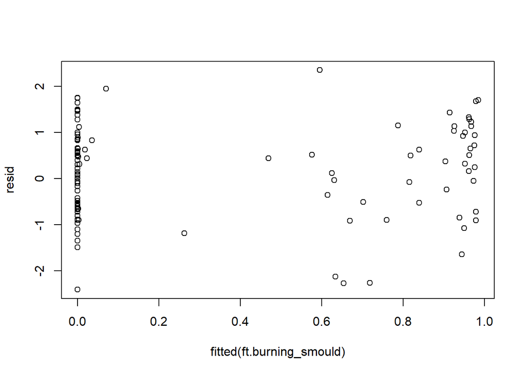

```r
sim= simulateResiduals(ft.burning_smould)
resid = residuals(sim, quantileFunction = qnorm, outlierValues = c(-7,7))
plot(resid~fitted(ft.burning_smould))
```

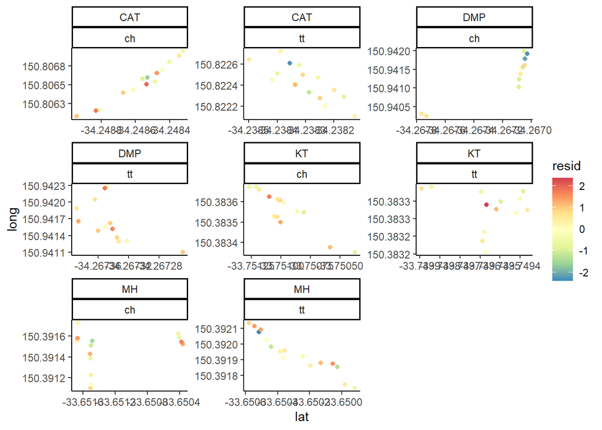

```r
burn_data_smould$resid = resid
ggplot(burn_data_smould, aes(lat,long, colour = resid)) +
  geom_point() +
  facet_wrap(swamp~  veg, scales = "free")+
  scale_colour_distiller(palette = "Spectral")+
  theme_classic()
```

### Inference

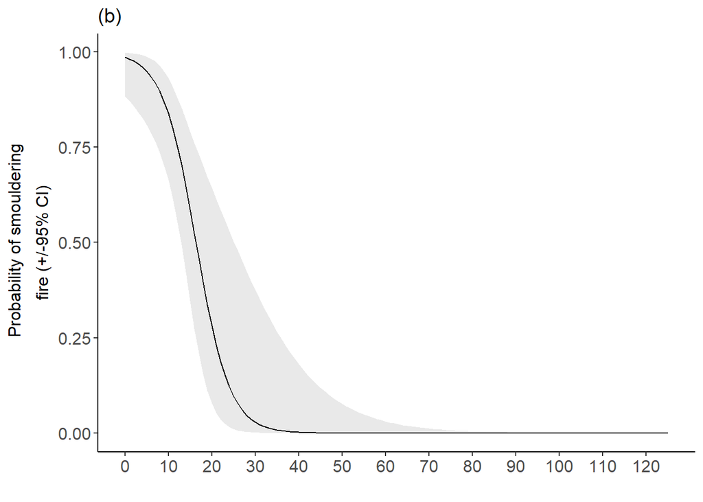

```r
em_grav_smould = emmip(ft.burning_smould, ~ volumetric_wc , type = "response",  CIs = TRUE,
      at = list(volumetric_wc = seq(0, 150,by=1)), plotit = FALSE)




#write.csv(em_grav_smould,file="em_grav_smould.csv")

smould_plot <- ggplot(em_grav_smould, aes(volumetric_wc, yvar)) +
  geom_ribbon(aes(ymin = LCL, ymax = UCL), alpha = 0.5, fill = "lightgrey")+
  geom_line()+
  #geom_point(colour = "grey25", data = burn_data_smould, aes(volumetric_wc,binomial_burn_status)) +
  ylab(expression(atop(paste("Probability of smouldering"), paste("fire (+/-95% CI)"))))+
  scale_x_continuous(breaks = seq(0, 120, by = 10), limits = c(0,125))+
  xlab("")+
 # geom_vline(xintercept = 50)+ #tells us what the value and CI are when grav moist is 50%
  theme(axis.text = element_text(size = 12))+
  theme(axis.title = element_text(size = 12))+
  theme(plot.title = element_text(size = 14))+
  theme(strip.text = element_text(size = 14))+
  theme(legend.text = element_text(size = 12))+
  labs(title = "(b)")+
    theme(panel.grid.major = element_blank(), panel.grid.minor = element_blank(),
        panel.background = element_blank(), axis.line = element_line(colour = "black"))
smould_plot
```

```r
# ggsave(plot = smould_plot, file = "../results/smould_plot.tiff" , width = 180, height = 150, units = "mm", device = "tiff")
  #geom_vline(xintercept = 10)#tells us what the value and CI are when grav moist is 10%
```

### Experimental

We can calculate an average probability of burning by multiplying the soil moisture for each day by the probability of burning for that soil moisture, and averaging across the days.

```r
probes_summary <- probes_sub %>%
  mutate(xvar = round(soil_moisture)) %>% #round to nearest integer
  group_by(Impact, xvar) %>%
  count() %>% # count how many days for each soil moisture value
  left_join(em_grav_smould) %>%
  mutate(pn_burn = yvar * n) %>% # multiply this histogram by probability of burning
  group_by(Impact) %>%
  summarise(n = sum(n), probn = sum(pn_burn)) %>%
  transmute(Impact, p_burn = probn/n) # averaging
probes_summary
```

| Impact | p_burn |
| --- | --- |
| Reference | 0.03119627 |
| Undermined | 0.06791599 |

The average (per day) probability of burning more than doubles, from 3.1% for reference to 6.8% for undermined.

We can then generate CI for the difference between Reference and Undermined probabilities by simulating from the posterior distribution of the model coefficients, and calculating a percentile confidence interval.

```r
library(mvtnorm)
library(tidyr)
K=100 #change to 1000 to get better estimate
set.seed(111024)
sim_pars<-rmvnorm(K,coef(ft.burning_smould),vcov(ft.burning_smould))

burning_probs <- data.frame(Reference = rep(NA, K), Undermined = NA)

for(i in 1:K){
  nu <- sim_pars[i,1]+em_grav_smould$volumetric_wc*sim_pars[i,2]
  p <- 1/(1+exp(-nu))
  sim_p <- data.frame(xvar =em_grav_smould$volumetric_wc, yvar = p)

  burning_probs[i,] <- probes_sub %>%
  mutate(xvar = round(soil_moisture)) %>% #round to nearest integer
  group_by(Impact, xvar) %>%
  count() %>% # count how many days for each soil moisture value
  left_join(sim_p) %>%
  mutate(pn_burn = yvar * n) %>% # multiply this histogram by probability of burning
  group_by(Impact) %>%
  summarise(n = sum(n), probn = sum(pn_burn)) %>%
  transmute(Impact, p_burn = probn/n) %>%
    pivot_wider(names_from = Impact, values_from = p_burn)
}
# Difference

c(probes_summary[2,2] / probes_summary[1,2],

quantile((burning_probs$Undermined / burning_probs$Reference), probs = c(0.025, 0.975)))
```

```
## $p_burn
## [1] 2.177055
##
## $`2.5%`
## [1] 1.961469
##
## $`97.5%`
## [1] 2.248042
```

The average (per day) probability of burning is more than double (ratio = 2.18, 95%CI = 1.96 - 2.25), from 3.1% for reference to 6.8% for undermined.

## Combine all fire types in a plot

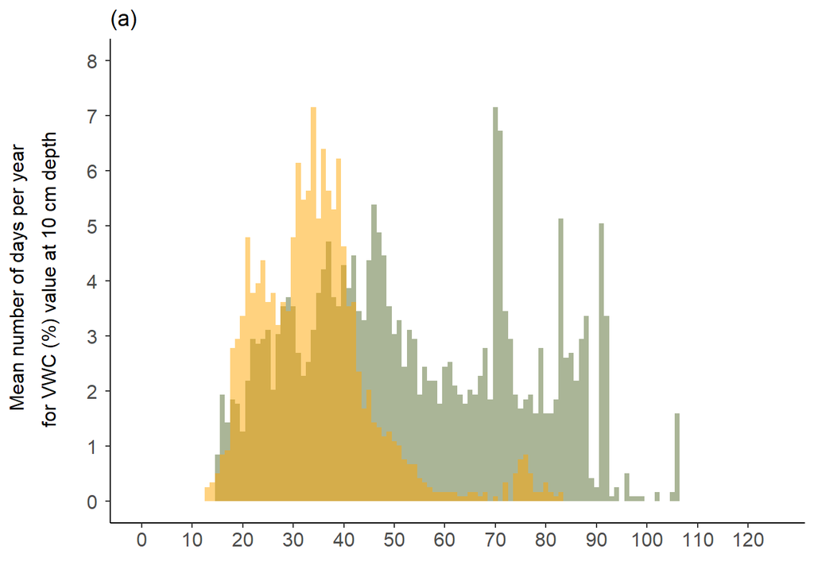

```r
# moisture_density <-
#   ggplot(probes_sub, aes(soil_moisture, fill = Impact)) + geom_density(alpha = 0.2)
# moisture_density

moisture_plot2 <- probes_sub %>%
  ggplot(aes(soil_moisture, fill = Impact))+
  # geom_histogram(aes(y=..density..), binwidth = 1) +
  geom_histogram(alpha = 0.5, aes(y=..count../sum(..count..)*365), binwidth = 1, position ='identity') +
  scale_fill_manual(values=c("darkolivegreen", "orange"))+
  #facet_grid(Impact ~ .)+
  theme_classic()+
  theme(legend.position = "none")+
    #xlab("Volumetric water content (%)")+ the next line silences the x axis label
  xlab("")+
    scale_x_continuous(breaks = seq(0, 120, by = 10), limits = c(0, 125))+
    scale_y_continuous(breaks = seq(0, 8, by =1), limits = c(0,8))+
  ylab(expression(atop(paste("Mean number of days per year"), paste("for VWC (%) value at 10 cm depth"))))+
    theme(axis.text = element_text(size = 12))+
  theme(axis.title = element_text(size = 12))+
  theme(plot.title = element_text(size = 14))+
  theme(strip.text = element_text(size = 14))+
  theme(legend.text = element_text(size = 12))+
  theme(axis.title.y = element_text(margin = margin(r = 15)))+
  theme(axis.text.y = element_text(margin = margin(0,5,0,0)))+
  labs(title = "(a)")+
    theme(panel.grid.major = element_blank(), panel.grid.minor = element_blank(),
        panel.background = element_blank(), axis.line = element_line(colour = "black"))#+
    #theme(plot.margin = unit(c(0,0,0,1), "cm"))

moisture_plot2
```

```r
#ggarrange(smould_plot, moisture_plot2, nrow = 2)
```

Smouldering plot

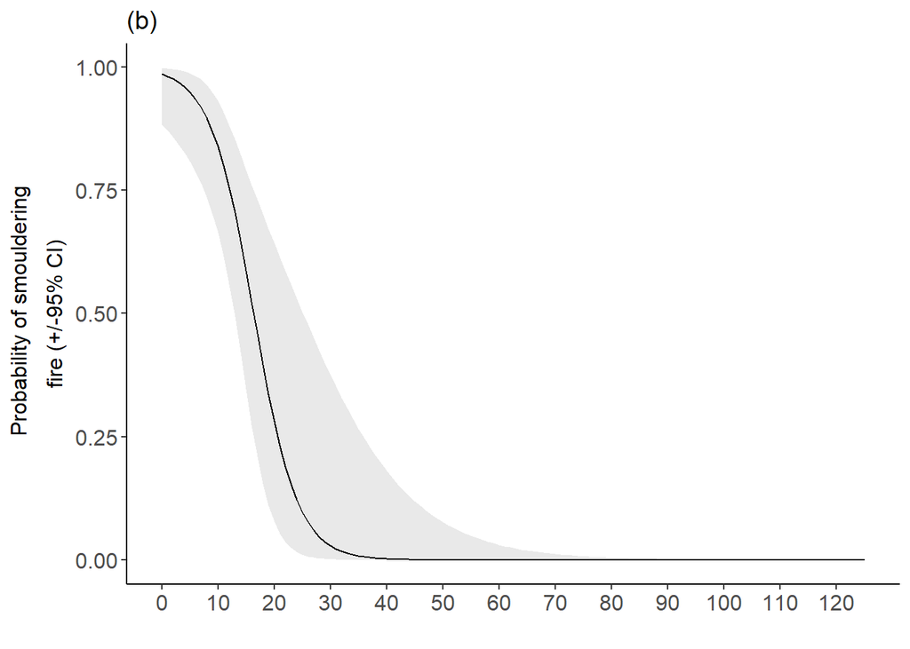

```r
em_grav_smould = emmip(ft.burning_smould, ~ volumetric_wc , type = "response",  CIs = TRUE,
      at = list(volumetric_wc = seq(0, 150,by=1)), plotit = FALSE)




#write.csv(em_grav_smould,file="em_grav_smould.csv")

smould_plot <- ggplot(em_grav_smould, aes(volumetric_wc, yvar)) +
  geom_ribbon(aes(ymin = LCL, ymax = UCL), alpha = 0.5, fill = "lightgrey")+
  geom_line()+
  #geom_point(colour = "grey25", data = burn_data_smould, aes(volumetric_wc,binomial_burn_status)) +
  ylab(expression(atop(paste("Probability of smouldering"), paste("fire (+/-95% CI)"))))+
  scale_x_continuous(breaks = seq(0, 120, by = 10), limits = c(0,125))+
  xlab("")+
 # geom_vline(xintercept = 50)+ #tells us what the value and CI are when grav moist is 50%
  theme(axis.text = element_text(size = 12))+
  theme(axis.title = element_text(size = 12))+
  theme(plot.title = element_text(size = 14))+
  theme(strip.text = element_text(size = 14))+
  theme(legend.text = element_text(size = 12))+
  labs(title = "(b)")+
    theme(panel.grid.major = element_blank(), panel.grid.minor = element_blank(),
        panel.background = element_blank(), axis.line = element_line(colour = "black"))
smould_plot
```

```r
# ggsave(plot = smould_plot, file = "../results/smould_plot.tiff" , width = 180, height = 150, units = "mm", device = "tiff")
  #geom_vline(xintercept = 10)#tells us what the value and CI are when grav moist is 10%
```

BAL40 plot

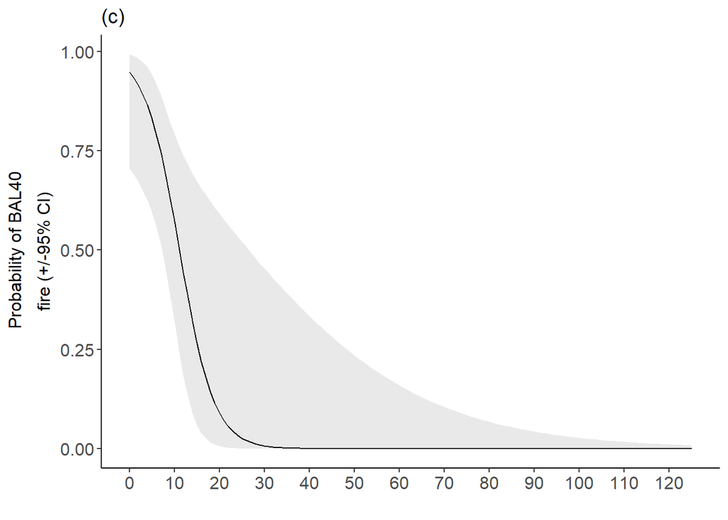

```r
em_grav_bal40 = emmip(ft.burning_bal40, ~ volumetric_wc , type = "response",  CIs = TRUE,
      at = list(volumetric_wc = seq(0, 150,by=1)), plotit = FALSE)




#write.csv(em_grav_bal40,file="em_grav_BAL40.csv")

BAL40_plot <- ggplot(em_grav_bal40, aes(volumetric_wc, yvar)) +
  geom_ribbon(aes(ymin = LCL, ymax = UCL), alpha = 0.5, fill = "lightgrey")+
  geom_line()+
  #geom_point(colour = "grey25", data = burn_data, aes(volumetric_wc,binomial_burn_status)) +
  ylab(expression(atop(paste("Probability of BAL40"), paste("fire (+/-95% CI)"))))+
  scale_x_continuous(breaks = seq(0, 120, by = 10), limits = c(0,125))+
  xlab("")+
 # geom_vline(xintercept = 50)+ #tells us what the value and CI are when grav moist is 50%
  theme(axis.text = element_text(size = 12))+
  theme(axis.title = element_text(size = 12))+
  theme(plot.title = element_text(size = 14))+
  theme(strip.text = element_text(size = 14))+
  theme(legend.text = element_text(size = 12))+
  labs(title = "(c)")+
    theme(panel.grid.major = element_blank(), panel.grid.minor = element_blank(),
        panel.background = element_blank(), axis.line = element_line(colour = "black"))
BAL40_plot
```

```r
# ggsave(plot = BAL40_plot, file = "../results/BAL40_plot.tiff" , width = 180, height = 150, units = "mm", device = "tiff")
  #geom_vline(xintercept = 10)#tells us what the value and CI are when grav moist is 10%
```

BalFZ plot

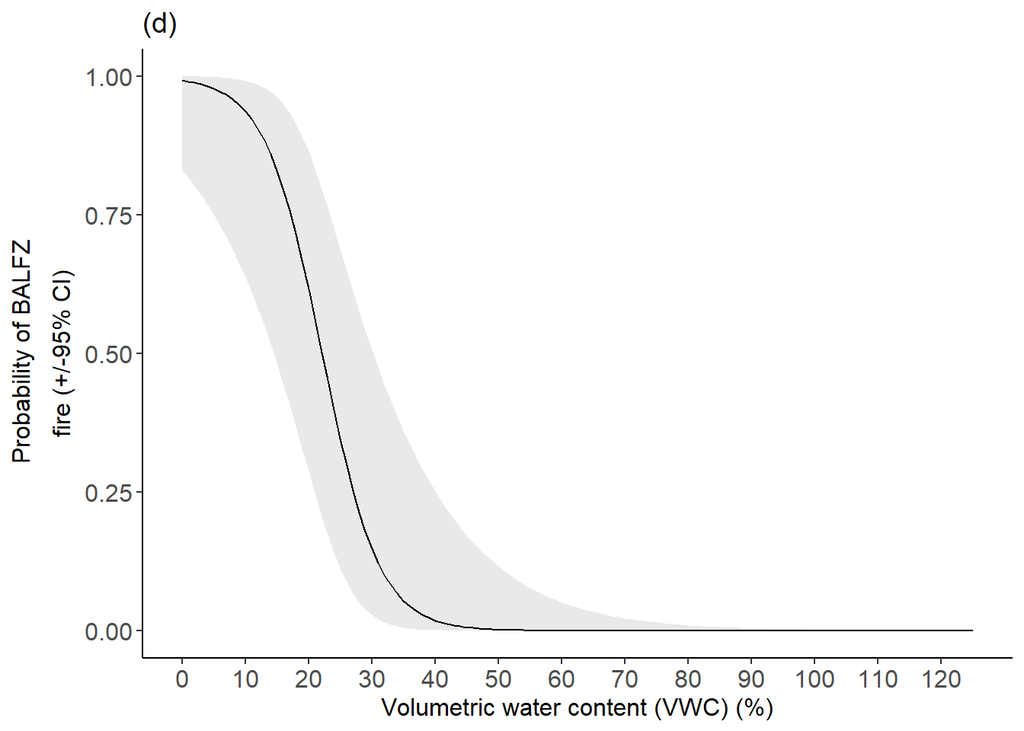

```r
em_grav_fz = emmip(ft.burning_fz, ~ volumetric_wc , type = "response",  CIs = TRUE,
      at = list(volumetric_wc = seq(0, 150,by=1)), plotit = FALSE)




#write.csv(em_grav_fz,file="em_grav_fz.csv")

BALFZ_plot <- ggplot(em_grav_fz, aes(volumetric_wc, yvar)) +
  geom_ribbon(aes(ymin = LCL, ymax = UCL), alpha = 0.5, fill = "lightgrey")+
  geom_line()+
  #geom_point(colour = "grey25", data = burn_data_fz, aes(volumetric_wc,binomial_burn_status)) +
  ylab(expression(atop(paste("Probability of BALFZ"), paste("fire (+/-95% CI)"))))+
  scale_x_continuous(breaks = seq(0, 120, by = 10), limits = c(0,125))+
  xlab("Volumetric water content (VWC) (%)")+
  # geom_vline(xintercept = 50)+ #tells us what the value and CI are when grav moist is 50%
  theme(axis.text = element_text(size = 12))+
  theme(axis.title = element_text(size = 12))+
  theme(plot.title = element_text(size = 14))+
  theme(strip.text = element_text(size = 14))+
  theme(legend.text = element_text(size = 12))+
  labs(title = "(d)")+
    theme(panel.grid.major = element_blank(), panel.grid.minor = element_blank(),
        panel.background = element_blank(), axis.line = element_line(colour = "black"))
BALFZ_plot
```

```r
# ggsave(plot = BALFZ_plot, file = "../results/BALFZ_plot.tiff" , width = 180, height = 150, units = "mm", device = "tiff")
  #geom_vline(xintercept = 10)#tells us what the value and CI are when grav moist is 10%
```

Combined figure

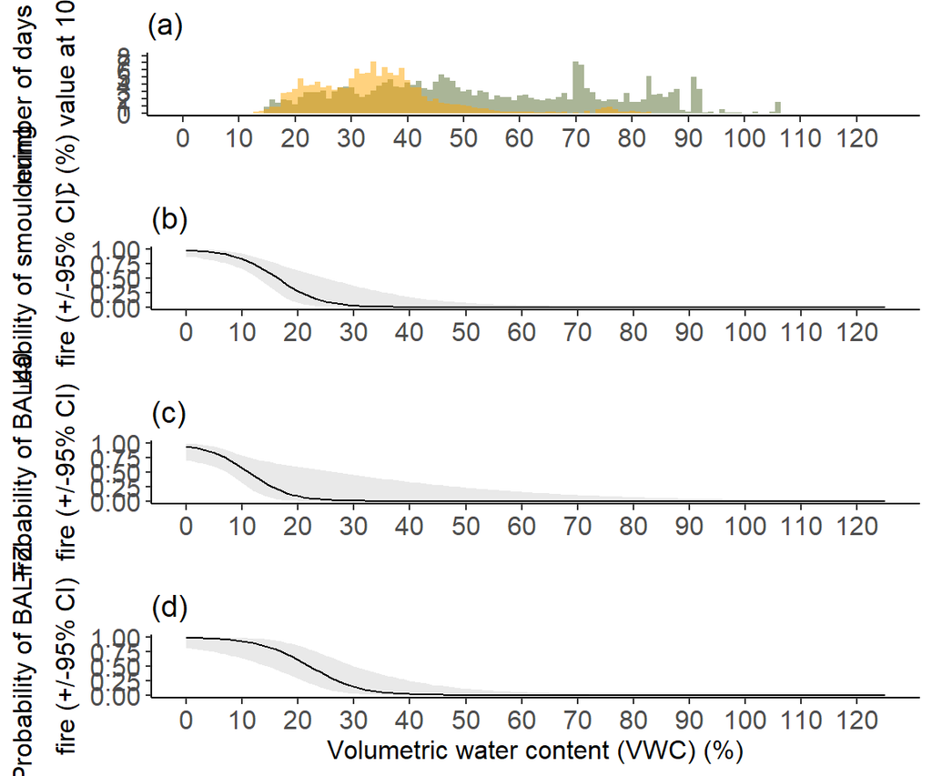

```r
comb_vmcBAL40_FZ_smould <- ggarrange(moisture_plot2, smould_plot, BAL40_plot, BALFZ_plot, nrow = 4)
comb_vmcBAL40_FZ_smould
```

```r
ggsave(plot = comb_vmcBAL40_FZ_smould, file = "../results/comb_vmcBAL40_FZ_smould_plot3.tiff" , width = 200, height = 280, units = "mm")
#ggsave(plot = comb_vmcBAL40_FZ_smould, file = "../results/comb_vmcBAL40_FZ_smould_plot3.svg" , width = 200, height = 280, units = "mm")
```